# Week 6

# Submitter - Himanshu Singh

# Fraud Waste Abuse Detection in Healthcare Insurance - Project Milestone 1

# Data Selection and EDA

## Problem Statement

The primary objective of this project is to develop a predictive model to identify Fraud, Waste, and Abuse (FWA) among healthcare providers. By analyzing claims data, the project aims to "Predict potentially fraudulent providers" while uncovering the most significant variables that signal suspicious behavior. This intelligence allows organizations to flag high-risk claims for in-depth investigation, ensuring that resources are directed toward the most likely instances of financial leakage.

## Problem Description

Healthcare insurance is a vital pillar of social stability, protecting citizens from the financial hardships of medical uncertainty. However, the integrity of both public and private insurance schemes is constantly threatened by Fraud, Waste, and Abuse (FWA):

Fraud: Intentional deception or misrepresentation, such as billing for services never rendered or "phantom" patients. Waste: Overutilization of services or practices that result in unnecessary costs, such as performing excessive diagnostic tests that are not medically required. Abuse: Actions that are inconsistent with sound fiscal, business, or medical practices, resulting in improper payment (e.g., upcoding or unbundling procedures).

FWA is often an organized crime involving collusion between providers, physicians, and beneficiaries. Specifically, Provider Fraud is a massive burden on Medicare; for instance, providers may exaggerate billing amounts or facilitate benefits for unauthorized individuals.

The cost of misidentification is high: failing to detect FWA leads to substantial financial losses, while incorrectly flagging legitimate providers (False Positives) causes administrative friction and delays essential patient care. A precise, data-driven approach is required to balance aggressive cost recovery with the smooth adjudication of valid claims.

### Real-Life Examples in FWA Detection

Fraud (Intentional Deception): A provider submits claims for a series of complex MRIs for patients who, according to demographic data, live 500 miles away and never visited the clinic. Data Mining Perspective: We can look for geospatial anomalies and a lack of corresponding primary care referrals.

Waste (Unnecessary Costs): A clinic consistently orders expensive "comprehensive metabolic panels" for every single patient visit, regardless of the diagnosis (e.g., even for a simple flu shot). Data Mining Perspective: This is identified through frequency analysis and comparing a provider's behavior against the "peer group" average for the same specialty.

Abuse (Improper Practice): A surgeon performs a single operation but bills for three separate "sub-procedures" to increase the payout (known as unbundling). Data Mining Perspective: We can use Association Rule Mining to find procedure codes that should logically be billed under a single global fee but are appearing as separate line items.

Source of data: Elsevier''s Mendeley Data repository is a participating member of the National Institutes of Health (NIH) Office of Data Science Strategy (ODSS) GREI project. liang, tim (2024), “HEALTHCARE PROVIDER FRAUD DETECTION ANALYSIS”, Mendeley Data, V1, doi: 10.17632/gsn2hyty37.1 https://data.mendeley.com/datasets/gsn2hyty37/1

```python
import pandas as pd
import os
import numpy as np
import matplotlib.pyplot as plt
import numpy as np
import seaborn as sns
```

```python
data = pd.read_csv('Train.csv')
data_beneficiary = pd.read_csv('Train_Beneficiarydata.csv')
data_inpatient = pd.read_csv('Train_Inpatientdata.csv')
data_outpatient = pd.read_csv('Train_Outpatientdata.csv')

print("data : ",data.shape)
print("beneficiary_data : ",data_beneficiary.shape)
print("inpatient_data : ",data_inpatient.shape)
print("outpatient_data : ",data_outpatient.shape)
```

```
data :  (5410, 2)
beneficiary_data :  (138556, 25)
inpatient_data :  (40474, 30)
outpatient_data :  (517737, 27)
```

# Exploratory Data Analysis

# 1 . Procedure Code and Diagnosis Codes Analysis

## Inpatient Records Data Analysis

### Inpatient Data - Inpatient Data refers to records for patients who have been formally admitted to a hospital or medical facility for at least one night.

```python
#Getting all the columns of Inpatient data
print('Columns in this dataset are : ')
print(data_inpatient.columns)

data_inpatient.head(5)
```

```
Columns in this dataset are :
Index(['BeneID', 'ClaimID', 'ClaimStartDt', 'ClaimEndDt', 'Provider',
       'InscClaimAmtReimbursed', 'AttendingPhysician', 'OperatingPhysician',
       'OtherPhysician', 'AdmissionDt', 'ClmAdmitDiagnosisCode',
       'DeductibleAmtPaid', 'DischargeDt', 'DiagnosisGroupCode',
       'ClmDiagnosisCode_1', 'ClmDiagnosisCode_2', 'ClmDiagnosisCode_3',
       'ClmDiagnosisCode_4', 'ClmDiagnosisCode_5', 'ClmDiagnosisCode_6',
       'ClmDiagnosisCode_7', 'ClmDiagnosisCode_8', 'ClmDiagnosisCode_9',
       'ClmDiagnosisCode_10', 'ClmProcedureCode_1', 'ClmProcedureCode_2',
       'ClmProcedureCode_3', 'ClmProcedureCode_4', 'ClmProcedureCode_5',
       'ClmProcedureCode_6'],
      dtype='object')
```

|  | BeneID | ClaimID | ClaimStartDt | ClaimEndDt | Provider | InscClaimAmtReimbursed | AttendingPhysician | OperatingPhysician | OtherPhysician | AdmissionDt | ... | ClmDiagnosisCode_7 | ClmDiagnosisCode_8 | ClmDiagnosisCode_9 | ClmDiagnosisCode_10 | ClmProcedureCode_1 | ClmProcedureCode_2 | ClmProcedureCode_3 | ClmProcedureCode_4 | ClmProcedureCode_5 | ClmProcedureCode_6 |
| --- | --- | --- | --- | --- | --- | --- | --- | --- | --- | --- | --- | --- | --- | --- | --- | --- | --- | --- | --- | --- | --- |
| 0 | BENE11001 | CLM46614 | 2009-04-12 | 2009-04-18 | PRV55912 | 26000 | PHY390922 | NaN | NaN | 2009-04-12 | ... | 2724 | 19889 | 5849 | NaN | NaN | NaN | NaN | NaN | NaN | NaN |
| 1 | BENE11001 | CLM66048 | 2009-08-31 | 2009-09-02 | PRV55907 | 5000 | PHY318495 | PHY318495 | NaN | 2009-08-31 | ... | NaN | NaN | NaN | NaN | 7092.0 | NaN | NaN | NaN | NaN | NaN |
| 2 | BENE11001 | CLM68358 | 2009-09-17 | 2009-09-20 | PRV56046 | 5000 | PHY372395 | NaN | PHY324689 | 2009-09-17 | ... | NaN | NaN | NaN | NaN | NaN | NaN | NaN | NaN | NaN | NaN |
| 3 | BENE11011 | CLM38412 | 2009-02-14 | 2009-02-22 | PRV52405 | 5000 | PHY369659 | PHY392961 | PHY349768 | 2009-02-14 | ... | 25062 | 40390 | 4019 | NaN | 331.0 | NaN | NaN | NaN | NaN | NaN |
| 4 | BENE11014 | CLM63689 | 2009-08-13 | 2009-08-30 | PRV56614 | 10000 | PHY379376 | PHY398258 | NaN | 2009-08-13 | ... | 5119 | 29620 | 20300 | NaN | 3893.0 | NaN | NaN | NaN | NaN | NaN |

5 rows × 30 columns

We will try to analyze the data we have

This data contains Diagnosis Code and Procedure Codes

- Diagnosis Codes (primarily ICD-10 codes) are the standardized alphanumeric strings used to describe a patient’s medical condition, symptoms, or injuries.
- Procedure Codes are standardized numeric or alphanumeric codes used to identify the specific medical, surgical, or diagnostic services provided to a patient. While Diagnosis Codes explain "why" the patient is there, Procedure Codes explain "what" was done to them.

Since there are multiple service and procedure code associated to each claim we will combine them together and sort, so that it doesn't give us multiple sets of same procedure and services

Eg : Knee Surgery will have Anaesthesia + Arthroscopically aided ACL reconstruction, the sort and combine will give us combination of procedure.

We will try to find which Procedure and Diagnonsis are the top reported in the dataset we got.

```python
# Function to analyse categorical columns

def analyse_cat_columns(dataset, col_to_analyse, prefix='', title='Distribution in percentage',
                        top_val=30, y_lim=None, color='green'):
    """Plots a bar graph for the percentage distribution of a categorical column."""

    # Calculate counts and convert to percentage in one step
    counts = dataset[col_to_analyse].value_counts().head(top_val)
    percentages = (counts / len(dataset)) * 100

    # Create the plot labels with the optional prefix
    labels = [f"{prefix}{label}" for label in percentages.index]

    # Plotting
    plt.figure(figsize=(15, 5))
    plt.bar(labels, percentages.values, color=color)

    # Formatting
    plt.title(title)
    plt.ylabel('Percentage (%)')
    plt.xlabel(col_to_analyse)
    plt.xticks(rotation=45)
    plt.grid(axis='y', linestyle='--', alpha=0.7)

    if y_lim is not None:
        plt.yticks(y_lim)

    plt.tight_layout()
    plt.show()
```

```python
# Select all columns that start with 'ClmProcedureCode'
proc_cols = [col for col in data_inpatient.columns if 'ClmProcedureCode' in col]

# Concatenate them all and drop NaNs
inpatient_df = pd.DataFrame(
    pd.concat([data_inpatient[col] for col in proc_cols], axis=0).dropna(),
    columns=['ProcedureCode']
)

print(f"Total Procedures Found: {inpatient_df.shape[0]}")

print(inpatient_df.shape)
```

```
Total Procedures Found: 29692
(29692, 1)
```

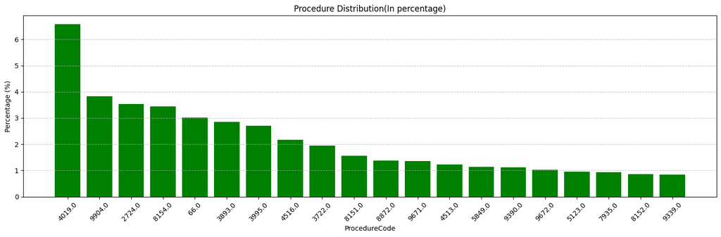

```python
analyse_cat_columns(inpatient_df,col_to_analyse='ProcedureCode' ,title = 'Procedure Distribution(In percentage)',top_val = 20)
```

# Conclusion

#### 4019.0 (Other biopsy of lymphatic structures) is the most used procedure code in the dataset. About 6% claims have that procedure code. Since this is the most common procedure, it should be the first target for "Peer Comparison" analysis to see if specific providers are billing it at a rate significantly higher than the 6.6% average

#### The top 5 procedures—4019, 9904 (Blood Transfusion), 2724 (Hip Replacement/Repair), 8154 (Total Knee Replacement), and 66 (CS Section/Other)—represent the core surgical and clinical volume. FWA Impact: High-cost procedures like 8154 and 2724 are high-risk areas for "Upcoding," where a simple repair might be billed as a complex total replacement.

```python
# Automatically grabs ClmDiagnosisCode_1 through ClmDiagnosisCode_10
diag_cols = data_inpatient.filter(like='ClmDiagnosisCode').columns

# Concatenate into a single Series and remove missing values
inpatient_diag_df = pd.DataFrame(
    pd.concat([data_inpatient[col] for col in diag_cols], axis=0).dropna(),
    columns=['DiagnosisCode']
)

print(f"Total Diagnosis Occurrences: {inpatient_diag_df.shape[0]}")
print(inpatient_diag_df.shape)
```

```
Total Diagnosis Occurrences: 327328
(327328, 1)
```

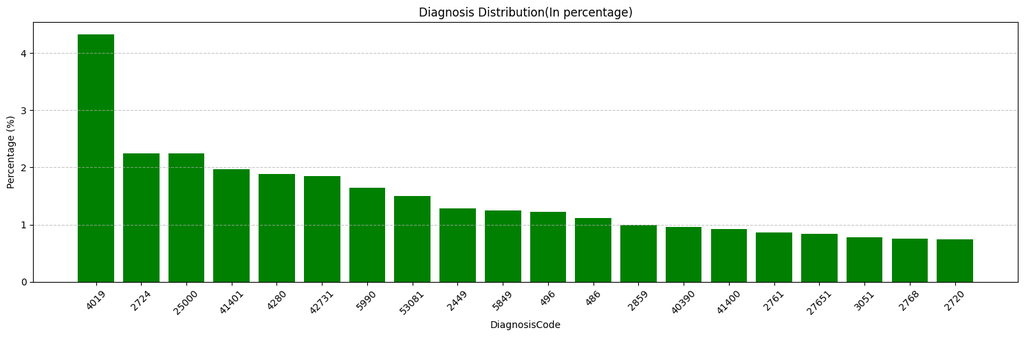

```python
analyse_cat_columns(inpatient_diag_df,col_to_analyse='DiagnosisCode' ,
                    title = 'Diagnosis Distribution(In percentage)',
                    top_val = 20, color ='green')
```

# Conclusion

#### Interestingly 4019 is the most used Diag code in the dataset which coincidently looks like the Procedure code 4019. About 4% claims have that diag code.

#### The top 5 diagnosis codes—4019 (Hypertension), 2724 (High Cholesterol), 25000 (Type 2 Diabetes), 41401 (Coronary Artery Disease), and 4280 (Congestive Heart Failure)—are all chronic conditions. FWA Insight: These are frequently used as "secondary" diagnoses to increase the complexity level of a claim, which can lead to higher reimbursement (a practice known as "Coding Creep").

# Outpatient Records Data Analysis

### Outpatient Data - In healthcare analytics, Outpatient Data refers to medical services provided to patients who are not admitted to a hospital (stays lasting less than 24 hours). This dataset is typically much larger and more "noisy" than inpatient data because it covers a vast range of routine interactions.

```python
#Getting all the columns of Outpatient data
print('Columns in this dataset are : ')
print(data_outpatient.columns)

data_outpatient.head(5)
```

```
Columns in this dataset are :
Index(['BeneID', 'ClaimID', 'ClaimStartDt', 'ClaimEndDt', 'Provider',
       'InscClaimAmtReimbursed', 'AttendingPhysician', 'OperatingPhysician',
       'OtherPhysician', 'ClmDiagnosisCode_1', 'ClmDiagnosisCode_2',
       'ClmDiagnosisCode_3', 'ClmDiagnosisCode_4', 'ClmDiagnosisCode_5',
       'ClmDiagnosisCode_6', 'ClmDiagnosisCode_7', 'ClmDiagnosisCode_8',
       'ClmDiagnosisCode_9', 'ClmDiagnosisCode_10', 'ClmProcedureCode_1',
       'ClmProcedureCode_2', 'ClmProcedureCode_3', 'ClmProcedureCode_4',
       'ClmProcedureCode_5', 'ClmProcedureCode_6', 'DeductibleAmtPaid',
       'ClmAdmitDiagnosisCode'],
      dtype='object')
```

|  | BeneID | ClaimID | ClaimStartDt | ClaimEndDt | Provider | InscClaimAmtReimbursed | AttendingPhysician | OperatingPhysician | OtherPhysician | ClmDiagnosisCode_1 | ... | ClmDiagnosisCode_9 | ClmDiagnosisCode_10 | ClmProcedureCode_1 | ClmProcedureCode_2 | ClmProcedureCode_3 | ClmProcedureCode_4 | ClmProcedureCode_5 | ClmProcedureCode_6 | DeductibleAmtPaid | ClmAdmitDiagnosisCode |
| --- | --- | --- | --- | --- | --- | --- | --- | --- | --- | --- | --- | --- | --- | --- | --- | --- | --- | --- | --- | --- | --- |
| 0 | BENE11002 | CLM624349 | 2009-10-11 | 2009-10-11 | PRV56011 | 30 | PHY326117 | NaN | NaN | 78943 | ... | NaN | NaN | NaN | NaN | NaN | NaN | NaN | NaN | 0 | 56409 |
| 1 | BENE11003 | CLM189947 | 2009-02-12 | 2009-02-12 | PRV57610 | 80 | PHY362868 | NaN | NaN | 6115 | ... | NaN | NaN | NaN | NaN | NaN | NaN | NaN | NaN | 0 | 79380 |
| 2 | BENE11003 | CLM438021 | 2009-06-27 | 2009-06-27 | PRV57595 | 10 | PHY328821 | NaN | NaN | 2723 | ... | NaN | NaN | NaN | NaN | NaN | NaN | NaN | NaN | 0 | NaN |
| 3 | BENE11004 | CLM121801 | 2009-01-06 | 2009-01-06 | PRV56011 | 40 | PHY334319 | NaN | NaN | 71988 | ... | NaN | NaN | NaN | NaN | NaN | NaN | NaN | NaN | 0 | NaN |
| 4 | BENE11004 | CLM150998 | 2009-01-22 | 2009-01-22 | PRV56011 | 200 | PHY403831 | NaN | NaN | 82382 | ... | NaN | NaN | NaN | NaN | NaN | NaN | NaN | NaN | 0 | 71947 |

5 rows × 27 columns

Same as Inpatient data, we will try to see which Diag and Procedure code are highly used in Outpatient data.

```python
# Select all columns that start with 'ClmProcedureCode'
proc_cols = [col for col in data_outpatient.columns if 'ClmProcedureCode' in col]

# Concatenate them all and drop NaNs
outpatient_df = pd.DataFrame(
    pd.concat([data_outpatient[col] for col in proc_cols], axis=0).dropna(),
    columns=['ProcedureCode']
)

print(f"Total Procedures Found: {outpatient_df.shape[0]}")

print(outpatient_df.shape)
```

```
Total Procedures Found: 204
(204, 1)
```

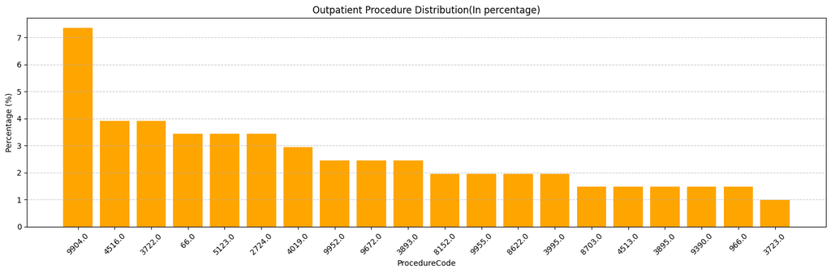

```python
analyse_cat_columns(outpatient_df,col_to_analyse='ProcedureCode' ,title = 'Outpatient Procedure Distribution(In percentage)',top_val = 20, color='orange')
```

# Conclusion

#### 9904.0 (Packed Cell Transfusion) is the most frequent outpatient procedure, appearing in 7.5% of records. FWA Insight: High volumes of transfusions in an outpatient setting are unusual and may suggest "Infusion Suite" fraud or billing for services that should require inpatient oversight.

```python
# Automatically grabs ClmDiagnosisCode_1 through ClmDiagnosisCode_10
diag_cols = data_outpatient.filter(like='ClmDiagnosisCode').columns

# Concatenate into a single Series and remove missing values
outpatient_diag_df = pd.DataFrame(
    pd.concat([data_outpatient[col] for col in diag_cols], axis=0).dropna(),
    columns=['DiagnosisCode']
)

print(f"Total Diagnosis Occurrences: {outpatient_diag_df.shape[0]}")
print(outpatient_diag_df.shape)
```

```
Total Diagnosis Occurrences: 1353388
(1353388, 1)
```

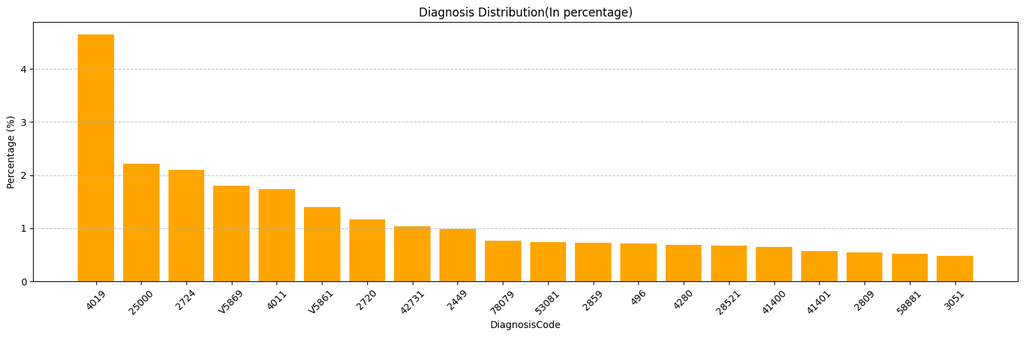

```python
analyse_cat_columns(outpatient_diag_df,col_to_analyse='DiagnosisCode' ,
                    title = 'Diagnosis Distribution(In percentage)',
                    top_val = 20, color ='orange')
```

# Conclusion

#### The top codes—4019, 25000 (Diabetes), and 2724 (High Cholesterol)—show that outpatient services are heavily utilized for managing long-term metabolic health.

#### The inclusion of V5869 (Long-term use of other medications) in the top 5 is highly significant. In outpatient data, this code is often used to justify frequent follow-up visits and lab tests. FWA Insight: Excessive use of V-codes alongside routine office visits can sometimes be a sign of "Churning," where providers schedule unnecessary appointments under the guise of "monitoring medication."

# 2 . Physician Analysis on number of claims

Why this is critical for Fraud, Waste, and Abuse (FWA) Identification of "Super-Billers": If one physician is filing significantly more claims than their peers, it could indicate "Phantom Billing" (billing for patients they never actually saw) or "Churning" (requiring unnecessary follow-up visits).

Capacity Analysis: In some fraud cases, data mining reveals that a single physician "performed" more surgeries in a 24-hour period than is humanly possible. This visualization helps spot those "impossible" volumes.

Audit Prioritization: Instead of auditing every provider, investigators use this specific list to prioritize "High-Yield" audits—focusing where the most money (and potentially the most fraud) is concentrated.

Attending Physician: The doctor who has primary responsibility for the patient's care and treatment during the entire hospital stay or clinic visit. They "own" the patient's record and oversee the overall medical plan.

Operating Physician: The specific doctor who performs a surgical or non-surgical procedure. In many outpatient cases, the Attending and Operating physician are the same person, but in complex cases, they differ.

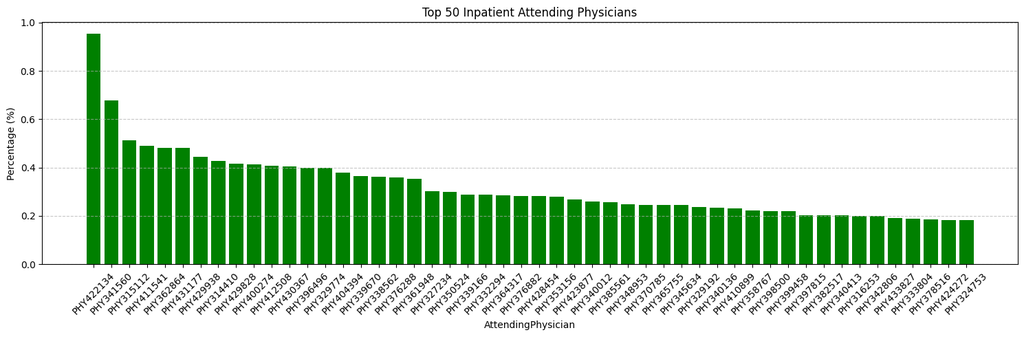

```python
# Analyse Attending Physicians in Inpatient Data

analyse_cat_columns(data_inpatient,
                    col_to_analyse='AttendingPhysician',
                    title='Top 50 Inpatient Attending Physicians',
                    top_val=50,
                    color='green')
```

# Conclusion

#### Analysis of the Attending Physician distribution reveals a high concentration of claims among the top 20 providers. In a fraud detection context, these 'Super-Billers' represent the highest financial risk. Further investigation is required to determine if their high volume is justified by their specialty or if it represents an anomaly such as excessive service utilization (Waste) or fictitious billing (Fraud).

#### Most patients are attended by physician PHY422134. Around 1% of the patients are attended by physician PHY422134

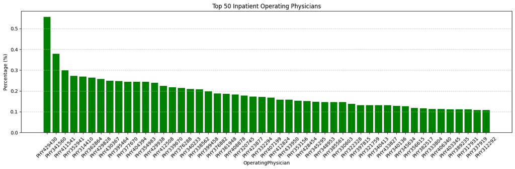

```python
# Analyse Operating Physicians in Inpatient Data

analyse_cat_columns(data_inpatient,
                    col_to_analyse='OperatingPhysician',
                    title='Top 50 Inpatient Operating Physicians',
                    top_val=50,
                    color='green')
```

# Conclusion

#### Most patients are operated by physician PHY429430. Around 0.55% of the patients are operated by physician PHY429430

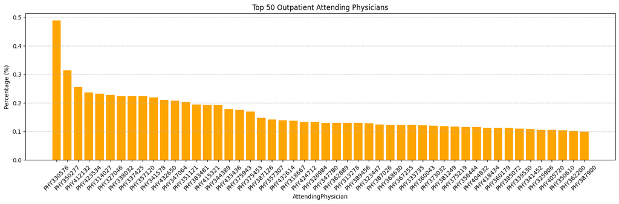

```python
# Analyse Attending Physicians in Outpatient Data

analyse_cat_columns(data_outpatient,
                    col_to_analyse='AttendingPhysician',
                    title='Top 50 Outpatient Attending Physicians',
                    top_val=50,
                    color='orange')
```

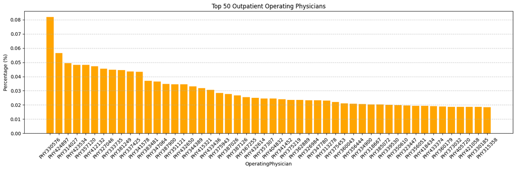

```python
# Analyse Operating  Physicians in Outpatient Data

analyse_cat_columns(data_outpatient,
                    col_to_analyse='OperatingPhysician',
                    title='Top 50 Outpatient Operating Physicians',
                    top_val=50,
                    color='orange')
```

# Conclusion

#### Most patients are operated by physician PHY330576 and attending provider is also same which a legit scenario is Outpatient claims

```python
# Analyzing the relationship between these two roles allows us to detect sophisticated fraud schemes:
# An Attending Physician consistently refers patients to the same Operating Physician for unnecessary surgeries.

# To analyze these together, we can create a "Pairing" feature in Python. This helps find "Closed Loops"
#  where two doctors are working together suspiciously often.

# Also for Outpatient claims mostly Attanding and Operating physicians are same.

# Create a unique 'Team' ID for every claim
data_outpatient['Physician_Team'] = (
    data_outpatient['AttendingPhysician'] + "_" + data_outpatient['OperatingPhysician']
)

# Find the most common teams
top_teams = data_outpatient['Physician_Team'].value_counts().head(10)
print(top_teams)
```

```
Physician_Team
PHY330576_PHY330576    406
PHY350277_PHY424897    293
PHY412132_PHY412132    227
PHY314027_PHY314027    214
PHY327046_PHY327046    186
PHY347064_PHY347064    183
PHY351121_PHY351121    179
PHY383481_PHY383481    179
PHY432650_PHY432650    174
PHY344389_PHY344389    165
Name: count, dtype: int64
```

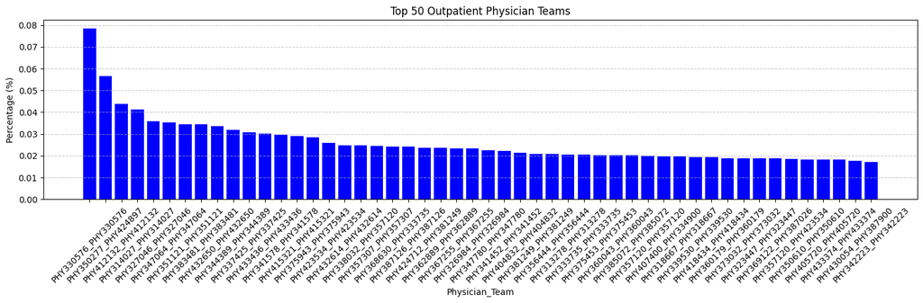

```python
analyse_cat_columns(data_outpatient,
                    col_to_analyse='Physician_Team',
                    title='Top 50 Outpatient Physician Teams',
                    top_val=50,
                    color='blue')
```

# Conclusion

#### The top combination is legit one where attending and operating physician providers are same. For others where they are different data needs to be analyzed.

# 3 . Analysis of Claim Amount Reimbursed

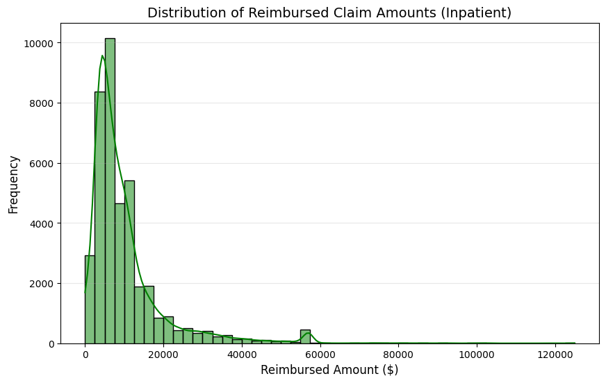

```python
# Checking distribution of Claim amount for Inpatient Claims

plt.figure(figsize=(10, 6))
# Using histplot for a more modern, detailed view
sns.histplot(data_inpatient['InscClaimAmtReimbursed'], kde=True, color='green', bins=50)

plt.title('Distribution of Reimbursed Claim Amounts (Inpatient)', fontsize=14)
plt.xlabel('Reimbursed Amount ($)', fontsize=12)
plt.ylabel('Frequency', fontsize=12)
plt.grid(axis='y', alpha=0.3)
plt.show()
```

# Conclusion

#### Right Skewness: Amount distribution is heavily "right-skewed," meaning the majority of claims are for small amounts, with a few very expensive outliers (like major surgeries).

#### Outliers: Claims that fall far to the right of the tail are the "High-Dollar" risks. These require the most scrutiny because a single fraudulent high-dollar claim can cause more damage than hundreds of small ones.

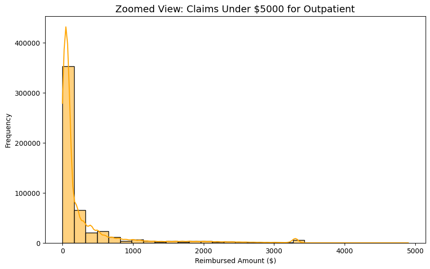

```python
# Checking distribution of Claim amount for Outpatient Claims

# Create a temporary view of only small claims
small_claims = data_outpatient[data_outpatient['InscClaimAmtReimbursed'] < 5000]

plt.figure(figsize=(10, 6))
sns.histplot(small_claims['InscClaimAmtReimbursed'], kde=True, color='orange', bins=30)

plt.title('Zoomed View: Claims Under $5000 for Outpatient', fontsize=14)
plt.xlabel('Reimbursed Amount ($)')
plt.ylabel('Frequency')
plt.show()
```

# Conclusion

# Here are the high-level conclusions we can derive by connecting three data points (codes, amount and Provider): (which can change in future based on further analysis)

#### Identifying "Upcoding" Patterns (Codes + Amounts) - By correlating Procedure Codes with the Reimbursed Amount, we can determine if a provider is billing for high-intensity services (like complex surgeries) when the diagnosis only supports a minor intervention.

#### Conclusion: If the average reimbursement for a specific provider is significantly higher than the peer mean for the same procedure code, it indicates potential Upcoding or the unbundling of services to inflate the claim.

#### Detection of "Impossible Volume" (Provider + Claims) - Analysis of the top-billing providers (like "Super-Biller" PHY422134) allows us to perform a capacity check.

#### Conclusion: If a provider's claim count exceeds the 99th percentile of their peer group, they are a high-risk outlier. If the number of procedures billed in a 24-hour window exceeds human capacity, we have a strong indicator of Phantom Billing (billing for services never rendered).

#### Specialization Anomaly (Codes + Provider) - By looking at which codes a specific provider uses most, we can spot "out-of-specialty" billing.

#### Conclusion: If a General Practitioner (Attending Physician) is consistently appearing as the Operating Physician for highly specialized codes (like 3722 - Heart Surgery), it flags a major Credentialing Fraud or Scope of Practice violation.

## We will not try to go in details of service codes, procedure code and specialty related to Provider. Our focus will be based on the dataset we have. But this also can be check to reduce FWA in Healthcare industry.